# DA5020 – Assignment 2

Saheed Bachu

```r
library(plyr)
library(dplyr)
library(nycflights13)
library(gapminder)
library(scales)
```

## Question 1

Explain the purpose of the following operators in R: =, ==, <- and %>%.

= and <- are assignment operators which assign the right item to the left item

```r
a = 10
a
```

```
[1] 10
```

```r
b <- 10
b
```

```
[1] 10
```

The == operator is used in comparison

```r
a == 10
```

```
[1] TRUE
```

```r
a == 11
```

```
[1] FALSE
```

The %>% (pipe) operator is used to apply the function after the pipe to the input before the pipe.

```r
sqrt(9) == 9 %>% sqrt()
```

```
[1] TRUE
```

## Question 2.1

Display the names and maximum category of all storms that occurred in 2004.

```r
storms %>%
  group_by(name) %>%
  filter(year     == 2004,
         category == max(category)) %>%
  select(name,
         category) %>%
  distinct()
```

| name | category |
| --- | --- |
| Alex | 3 |
| Charley | 4 |
| Gaston | 1 |
| Hermine | 0 |
| Ivan | 5 |
| AL102004 | -1 |
| Jeanne | 3 |
| Karl | 4 |
| Lisa | 1 |
| Matthew | 0 |

## Question 2.2

Display the names of all hurricanes (i.e. category > 0) that occurred in 2015.

```r
storms %>%
    filter(year == 2015,
           category > 0) %>%
  distinct(name)
```

| name |
| --- |
| Danny |
| Fred |
| Joaquin |
| Kate |

## Question 2.3

Filter the data to the year 2005 and group all hurricanes by the month of occurrence. Display the maximum wind speeds and category for each. Use the data to perform the following:

1. Display the output in descending order using the maximum wind speed.

```r
storms_2005 <-
  storms %>%
    group_by(month) %>%
    filter(year     == 2005,
           wind     == max(wind),
           category == max(category),
           category > 0) %>%
    select(name,
           year,
           month,
           wind,
           category) %>%
    distinct() %>%
  arrange(desc(wind))
storms_2005
```

| name | year | month | wind | category |
| --- | --- | --- | --- | --- |
| Wilma | 2005 | 10 | 160 | 5 |
| Katrina | 2005 | 8 | 150 | 5 |
| Emily | 2005 | 7 | 140 | 5 |
| Epsilon | 2005 | 12 | 75 | 1 |

2. Visualize the results using a bar/column chart.

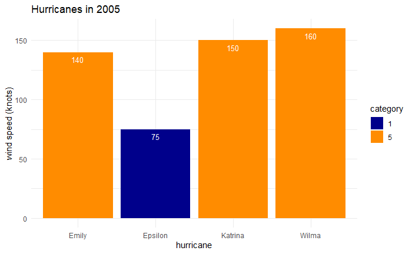

```r
ggplot(
  data = storms_2005,
  aes(x    = name,
      y    = wind,
      fill = category)) +
  geom_bar(stat = "identity") +
  geom_text(aes(label = wind),
            vjust = 1.6,
            color = "white",
            size  = 3.5) +
  theme_minimal() +
  scale_fill_manual(values = c("darkblue", "darkorange")) +
  labs(title = "Hurricanes in 2005",
       x     = "hurricane",
       y     = "wind speed (knots)")
```

## Question 2.4

Extract data for hurricane ‘Gilbert’ (i.e. name = ‘Gilbert’). Create a scatterplot with wind speed on the x axis, pressure on the y axis and assign the color (for each point) to the category.

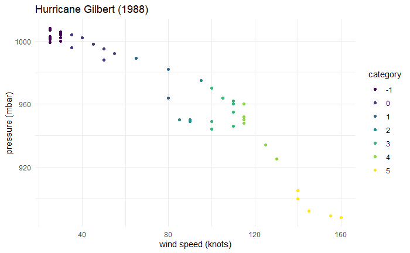

```r
ggplot(
  data = storms %>% filter(name == "Gilbert"),
  aes(x     = wind,
      y     = pressure,
      color = category)
) + geom_point() +
  theme_minimal() +
  labs(title = "Hurricane Gilbert (1988)",
       x     = "wind speed (knots)",
       y     = "pressure (mbar)")
```

What is the relationship between air pressure, wind speed and the hurricane category?

Wind speed and hurricane category are inversely proportional to air pressure.

## Question 3 (5.2.4 Exercises #1)

Find all flights that:

1. Had an arrival delay of two or more hours

```r
flights %>% filter(arr_delay >= 120)
```

| year | month | day | dep_time | sched_dep_time | dep_delay | arr_time | sched_arr_time | arr_delay | carrier | flight | tailnum | origin | dest | air_time | distance | hour | minute | time_hour |
| --- | --- | --- | --- | --- | --- | --- | --- | --- | --- | --- | --- | --- | --- | --- | --- | --- | --- | --- |
| 2013 | 1 | 1 | 811 | 630 | 101 | 1047 | 830 | 137 | MQ | 4576 | N531MQ | LGA | CLT | 118 | 544 | 6 | 30 | 2013-01-01 06:00:00 |
| 2013 | 1 | 1 | 848 | 1835 | 853 | 1001 | 1950 | 851 | MQ | 3944 | N942MQ | JFK | BWI | 41 | 184 | 18 | 35 | 2013-01-01 18:00:00 |
| 2013 | 1 | 1 | 957 | 733 | 144 | 1056 | 853 | 123 | UA | 856 | N534UA | EWR | BOS | 37 | 200 | 7 | 33 | 2013-01-01 07:00:00 |
| 2013 | 1 | 1 | 1114 | 900 | 134 | 1447 | 1222 | 145 | UA | 1086 | N76502 | LGA | IAH | 248 | 1416 | 9 | 0 | 2013-01-01 09:00:00 |
| 2013 | 1 | 1 | 1505 | 1310 | 115 | 1638 | 1431 | 127 | EV | 4497 | N17984 | EWR | RIC | 63 | 277 | 13 | 10 | 2013-01-01 13:00:00 |
| 2013 | 1 | 1 | 1525 | 1340 | 105 | 1831 | 1626 | 125 | B6 | 525 | N231JB | EWR | MCO | 152 | 937 | 13 | 40 | 2013-01-01 13:00:00 |
| 2013 | 1 | 1 | 1549 | 1445 | 64 | 1912 | 1656 | 136 | EV | 4181 | N21197 | EWR | MCI | 234 | 1092 | 14 | 45 | 2013-01-01 14:00:00 |
| 2013 | 1 | 1 | 1558 | 1359 | 119 | 1718 | 1515 | 123 | EV | 5712 | N826AS | JFK | IAD | 53 | 228 | 13 | 59 | 2013-01-01 13:00:00 |
| 2013 | 1 | 1 | 1732 | 1630 | 62 | 2028 | 1825 | 123 | EV | 4092 | N16911 | EWR | DAY | 119 | 533 | 16 | 30 | 2013-01-01 16:00:00 |
| 2013 | 1 | 1 | 1803 | 1620 | 103 | 2008 | 1750 | 138 | MQ | 4622 | N504MQ | LGA | BNA | 154 | 764 | 16 | 20 | 2013-01-01 16:00:00 |

[output cut: 990 more lines]

2. Flew to Houston (IAH or HOU)

```r
flights %>% filter(dest %in% c("IAH", "HOU"))
```

| year | month | day | dep_time | sched_dep_time | dep_delay | arr_time | sched_arr_time | arr_delay | carrier | flight | tailnum | origin | dest | air_time | distance | hour | minute | time_hour |
| --- | --- | --- | --- | --- | --- | --- | --- | --- | --- | --- | --- | --- | --- | --- | --- | --- | --- | --- |
| 2013 | 1 | 1 | 517 | 515 | 2 | 830 | 819 | 11 | UA | 1545 | N14228 | EWR | IAH | 227 | 1400 | 5 | 15 | 2013-01-01 05:00:00 |
| 2013 | 1 | 1 | 533 | 529 | 4 | 850 | 830 | 20 | UA | 1714 | N24211 | LGA | IAH | 227 | 1416 | 5 | 29 | 2013-01-01 05:00:00 |
| 2013 | 1 | 1 | 623 | 627 | -4 | 933 | 932 | 1 | UA | 496 | N459UA | LGA | IAH | 229 | 1416 | 6 | 27 | 2013-01-01 06:00:00 |
| 2013 | 1 | 1 | 728 | 732 | -4 | 1041 | 1038 | 3 | UA | 473 | N488UA | LGA | IAH | 238 | 1416 | 7 | 32 | 2013-01-01 07:00:00 |
| 2013 | 1 | 1 | 739 | 739 | 0 | 1104 | 1038 | 26 | UA | 1479 | N37408 | EWR | IAH | 249 | 1400 | 7 | 39 | 2013-01-01 07:00:00 |
| 2013 | 1 | 1 | 908 | 908 | 0 | 1228 | 1219 | 9 | UA | 1220 | N12216 | EWR | IAH | 233 | 1400 | 9 | 8 | 2013-01-01 09:00:00 |
| 2013 | 1 | 1 | 1028 | 1026 | 2 | 1350 | 1339 | 11 | UA | 1004 | N76508 | LGA | IAH | 237 | 1416 | 10 | 26 | 2013-01-01 10:00:00 |
| 2013 | 1 | 1 | 1044 | 1045 | -1 | 1352 | 1351 | 1 | UA | 455 | N667UA | EWR | IAH | 229 | 1400 | 10 | 45 | 2013-01-01 10:00:00 |
| 2013 | 1 | 1 | 1114 | 900 | 134 | 1447 | 1222 | 145 | UA | 1086 | N76502 | LGA | IAH | 248 | 1416 | 9 | 0 | 2013-01-01 09:00:00 |
| 2013 | 1 | 1 | 1205 | 1200 | 5 | 1503 | 1505 | -2 | UA | 1461 | N39418 | EWR | IAH | 221 | 1400 | 12 | 0 | 2013-01-01 12:00:00 |

[output cut: 990 more lines]

3. Were operated by United, American, or Delta

```r
flights %>% filter(carrier %in% c("UA", "AA", "DL"))
```

| year | month | day | dep_time | sched_dep_time | dep_delay | arr_time | sched_arr_time | arr_delay | carrier | flight | tailnum | origin | dest | air_time | distance | hour | minute | time_hour |
| --- | --- | --- | --- | --- | --- | --- | --- | --- | --- | --- | --- | --- | --- | --- | --- | --- | --- | --- |
| 2013 | 1 | 1 | 517 | 515 | 2 | 830 | 819 | 11 | UA | 1545 | N14228 | EWR | IAH | 227 | 1400 | 5 | 15 | 2013-01-01 05:00:00 |
| 2013 | 1 | 1 | 533 | 529 | 4 | 850 | 830 | 20 | UA | 1714 | N24211 | LGA | IAH | 227 | 1416 | 5 | 29 | 2013-01-01 05:00:00 |
| 2013 | 1 | 1 | 542 | 540 | 2 | 923 | 850 | 33 | AA | 1141 | N619AA | JFK | MIA | 160 | 1089 | 5 | 40 | 2013-01-01 05:00:00 |
| 2013 | 1 | 1 | 554 | 600 | -6 | 812 | 837 | -25 | DL | 461 | N668DN | LGA | ATL | 116 | 762 | 6 | 0 | 2013-01-01 06:00:00 |
| 2013 | 1 | 1 | 554 | 558 | -4 | 740 | 728 | 12 | UA | 1696 | N39463 | EWR | ORD | 150 | 719 | 5 | 58 | 2013-01-01 05:00:00 |
| 2013 | 1 | 1 | 558 | 600 | -2 | 753 | 745 | 8 | AA | 301 | N3ALAA | LGA | ORD | 138 | 733 | 6 | 0 | 2013-01-01 06:00:00 |
| 2013 | 1 | 1 | 558 | 600 | -2 | 924 | 917 | 7 | UA | 194 | N29129 | JFK | LAX | 345 | 2475 | 6 | 0 | 2013-01-01 06:00:00 |
| 2013 | 1 | 1 | 558 | 600 | -2 | 923 | 937 | -14 | UA | 1124 | N53441 | EWR | SFO | 361 | 2565 | 6 | 0 | 2013-01-01 06:00:00 |
| 2013 | 1 | 1 | 559 | 600 | -1 | 941 | 910 | 31 | AA | 707 | N3DUAA | LGA | DFW | 257 | 1389 | 6 | 0 | 2013-01-01 06:00:00 |
| 2013 | 1 | 1 | 559 | 600 | -1 | 854 | 902 | -8 | UA | 1187 | N76515 | EWR | LAS | 337 | 2227 | 6 | 0 | 2013-01-01 06:00:00 |

[output cut: 990 more lines]

4. Departed in summer (July, August, and September)

```r
flights %>% filter(month %in% c(7, 8, 9))
```

| year | month | day | dep_time | sched_dep_time | dep_delay | arr_time | sched_arr_time | arr_delay | carrier | flight | tailnum | origin | dest | air_time | distance | hour | minute | time_hour |
| --- | --- | --- | --- | --- | --- | --- | --- | --- | --- | --- | --- | --- | --- | --- | --- | --- | --- | --- |
| 2013 | 7 | 1 | 1 | 2029 | 212 | 236 | 2359 | 157 | B6 | 915 | N653JB | JFK | SFO | 315 | 2586 | 20 | 29 | 2013-07-01 20:00:00 |
| 2013 | 7 | 1 | 2 | 2359 | 3 | 344 | 344 | 0 | B6 | 1503 | N805JB | JFK | SJU | 200 | 1598 | 23 | 59 | 2013-07-01 23:00:00 |
| 2013 | 7 | 1 | 29 | 2245 | 104 | 151 | 1 | 110 | B6 | 234 | N348JB | JFK | BTV | 66 | 266 | 22 | 45 | 2013-07-01 22:00:00 |
| 2013 | 7 | 1 | 43 | 2130 | 193 | 322 | 14 | 188 | B6 | 1371 | N794JB | LGA | FLL | 143 | 1076 | 21 | 30 | 2013-07-01 21:00:00 |
| 2013 | 7 | 1 | 44 | 2150 | 174 | 300 | 100 | 120 | AA | 185 | N324AA | JFK | LAX | 297 | 2475 | 21 | 50 | 2013-07-01 21:00:00 |
| 2013 | 7 | 1 | 46 | 2051 | 235 | 304 | 2358 | 186 | B6 | 165 | N640JB | JFK | PDX | 304 | 2454 | 20 | 51 | 2013-07-01 20:00:00 |
| 2013 | 7 | 1 | 48 | 2001 | 287 | 308 | 2305 | 243 | VX | 415 | N627VA | JFK | LAX | 298 | 2475 | 20 | 1 | 2013-07-01 20:00:00 |
| 2013 | 7 | 1 | 58 | 2155 | 183 | 335 | 43 | 172 | B6 | 425 | N535JB | JFK | TPA | 140 | 1005 | 21 | 55 | 2013-07-01 21:00:00 |
| 2013 | 7 | 1 | 100 | 2146 | 194 | 327 | 30 | 177 | B6 | 1183 | N531JB | JFK | MCO | 126 | 944 | 21 | 46 | 2013-07-01 21:00:00 |
| 2013 | 7 | 1 | 100 | 2245 | 135 | 337 | 135 | 122 | B6 | 623 | N663JB | JFK | LAX | 304 | 2475 | 22 | 45 | 2013-07-01 22:00:00 |

[output cut: 990 more lines]

5. Arrived more than two hours late, but didn’t leave late

```r
flights %>% filter(dep_delay == 0,
                   arr_delay > 120)
```

| year | month | day | dep_time | sched_dep_time | dep_delay | arr_time | sched_arr_time | arr_delay | carrier | flight | tailnum | origin | dest | air_time | distance | hour | minute | time_hour |
| --- | --- | --- | --- | --- | --- | --- | --- | --- | --- | --- | --- | --- | --- | --- | --- | --- | --- | --- |
| 2013 | 10 | 7 | 1350 | 1350 | 0 | 1736 | 1526 | 130 | EV | 5181 | N611QX | LGA | MSN | 117 | 812 | 13 | 50 | 2013-10-07 13:00:00 |
| 2013 | 5 | 23 | 1810 | 1810 | 0 | 2208 | 2000 | 128 | MQ | 4626 | N525MQ | LGA | CMH | 82 | 479 | 18 | 10 | 2013-05-23 18:00:00 |
| 2013 | 7 | 1 | 905 | 905 | 0 | 1443 | 1223 | 140 | DL | 1057 | N337NB | LGA | MIA | 183 | 1096 | 9 | 5 | 2013-07-01 09:00:00 |

6. Were delayed by at least an hour, but made up over 30 minutes in flight.

```r
flights %>% filter(dep_delay >= 60,
                   arr_delay < 30)
```

| year | month | day | dep_time | sched_dep_time | dep_delay | arr_time | sched_arr_time | arr_delay | carrier | flight | tailnum | origin | dest | air_time | distance | hour | minute | time_hour |
| --- | --- | --- | --- | --- | --- | --- | --- | --- | --- | --- | --- | --- | --- | --- | --- | --- | --- | --- |
| 2013 | 1 | 3 | 1850 | 1745 | 65 | 2148 | 2120 | 28 | AA | 177 | N332AA | JFK | SFO | 314 | 2586 | 17 | 45 | 2013-01-03 17:00:00 |
| 2013 | 1 | 3 | 1950 | 1845 | 65 | 2228 | 2227 | 1 | B6 | 91 | N636JB | JFK | OAK | 319 | 2576 | 18 | 45 | 2013-01-03 18:00:00 |
| 2013 | 1 | 3 | 2015 | 1915 | 60 | 2135 | 2111 | 24 | 9E | 3525 | N903XJ | JFK | ORD | 110 | 740 | 19 | 15 | 2013-01-03 19:00:00 |
| 2013 | 1 | 6 | 1019 | 900 | 79 | 1558 | 1530 | 28 | HA | 51 | N385HA | JFK | HNL | 611 | 4983 | 9 | 0 | 2013-01-06 09:00:00 |
| 2013 | 1 | 7 | 1543 | 1430 | 73 | 1758 | 1735 | 23 | AA | 883 | N4XBAA | EWR | DFW | 177 | 1372 | 14 | 30 | 2013-01-07 14:00:00 |
| 2013 | 1 | 11 | 1020 | 920 | 60 | 1311 | 1245 | 26 | AA | 721 | N434AA | LGA | DFW | 201 | 1389 | 9 | 20 | 2013-01-11 09:00:00 |
| 2013 | 1 | 12 | 1706 | 1600 | 66 | 1949 | 1927 | 22 | DL | 2139 | N982DL | LGA | MIA | 141 | 1096 | 16 | 0 | 2013-01-12 16:00:00 |
| 2013 | 1 | 12 | 1953 | 1845 | 68 | 2154 | 2137 | 17 | 9E | 3369 | N919XJ | JFK | MSY | 165 | 1182 | 18 | 45 | 2013-01-12 18:00:00 |
| 2013 | 1 | 19 | 1456 | 1355 | 61 | 1636 | 1615 | 21 | EV | 5469 | N724EV | LGA | MEM | 137 | 963 | 13 | 55 | 2013-01-19 13:00:00 |
| 2013 | 1 | 21 | 1531 | 1430 | 61 | 1843 | 1815 | 28 | DL | 2126 | N710TW | JFK | SFO | 345 | 2586 | 14 | 30 | 2013-01-21 14:00:00 |

[output cut: 196 more lines]

7. Departed between midnight and 6am (inclusive)

```r
flights %>% filter(dep_time <= 600 | dep_time == 2400)
```

| year | month | day | dep_time | sched_dep_time | dep_delay | arr_time | sched_arr_time | arr_delay | carrier | flight | tailnum | origin | dest | air_time | distance | hour | minute | time_hour |
| --- | --- | --- | --- | --- | --- | --- | --- | --- | --- | --- | --- | --- | --- | --- | --- | --- | --- | --- |
| 2013 | 1 | 1 | 517 | 515 | 2 | 830 | 819 | 11 | UA | 1545 | N14228 | EWR | IAH | 227 | 1400 | 5 | 15 | 2013-01-01 05:00:00 |
| 2013 | 1 | 1 | 533 | 529 | 4 | 850 | 830 | 20 | UA | 1714 | N24211 | LGA | IAH | 227 | 1416 | 5 | 29 | 2013-01-01 05:00:00 |
| 2013 | 1 | 1 | 542 | 540 | 2 | 923 | 850 | 33 | AA | 1141 | N619AA | JFK | MIA | 160 | 1089 | 5 | 40 | 2013-01-01 05:00:00 |
| 2013 | 1 | 1 | 544 | 545 | -1 | 1004 | 1022 | -18 | B6 | 725 | N804JB | JFK | BQN | 183 | 1576 | 5 | 45 | 2013-01-01 05:00:00 |
| 2013 | 1 | 1 | 554 | 600 | -6 | 812 | 837 | -25 | DL | 461 | N668DN | LGA | ATL | 116 | 762 | 6 | 0 | 2013-01-01 06:00:00 |
| 2013 | 1 | 1 | 554 | 558 | -4 | 740 | 728 | 12 | UA | 1696 | N39463 | EWR | ORD | 150 | 719 | 5 | 58 | 2013-01-01 05:00:00 |
| 2013 | 1 | 1 | 555 | 600 | -5 | 913 | 854 | 19 | B6 | 507 | N516JB | EWR | FLL | 158 | 1065 | 6 | 0 | 2013-01-01 06:00:00 |
| 2013 | 1 | 1 | 557 | 600 | -3 | 709 | 723 | -14 | EV | 5708 | N829AS | LGA | IAD | 53 | 229 | 6 | 0 | 2013-01-01 06:00:00 |
| 2013 | 1 | 1 | 557 | 600 | -3 | 838 | 846 | -8 | B6 | 79 | N593JB | JFK | MCO | 140 | 944 | 6 | 0 | 2013-01-01 06:00:00 |
| 2013 | 1 | 1 | 558 | 600 | -2 | 753 | 745 | 8 | AA | 301 | N3ALAA | LGA | ORD | 138 | 733 | 6 | 0 | 2013-01-01 06:00:00 |

[output cut: 990 more lines]

## Question 3 (5.3.1 Exercises)

1. How could you use arrange() to sort all missing values to the start? (Hint: use is.na()).

```r
df <- tibble(x = c(5, 2, NA))
df %>% arrange(desc(is.na(df$x)))
```

| x |
| --- |
| NA |
| 5 |
| 2 |

2. Sort flights to find the most delayed flights.

```r
flights %>% arrange(desc(dep_delay))
```

| year | month | day | dep_time | sched_dep_time | dep_delay | arr_time | sched_arr_time | arr_delay | carrier | flight | tailnum | origin | dest | air_time | distance | hour | minute | time_hour |
| --- | --- | --- | --- | --- | --- | --- | --- | --- | --- | --- | --- | --- | --- | --- | --- | --- | --- | --- |
| 2013 | 1 | 9 | 641 | 900 | 1301 | 1242 | 1530 | 1272 | HA | 51 | N384HA | JFK | HNL | 640 | 4983 | 9 | 0 | 2013-01-09 09:00:00 |
| 2013 | 6 | 15 | 1432 | 1935 | 1137 | 1607 | 2120 | 1127 | MQ | 3535 | N504MQ | JFK | CMH | 74 | 483 | 19 | 35 | 2013-06-15 19:00:00 |
| 2013 | 1 | 10 | 1121 | 1635 | 1126 | 1239 | 1810 | 1109 | MQ | 3695 | N517MQ | EWR | ORD | 111 | 719 | 16 | 35 | 2013-01-10 16:00:00 |
| 2013 | 9 | 20 | 1139 | 1845 | 1014 | 1457 | 2210 | 1007 | AA | 177 | N338AA | JFK | SFO | 354 | 2586 | 18 | 45 | 2013-09-20 18:00:00 |
| 2013 | 7 | 22 | 845 | 1600 | 1005 | 1044 | 1815 | 989 | MQ | 3075 | N665MQ | JFK | CVG | 96 | 589 | 16 | 0 | 2013-07-22 16:00:00 |
| 2013 | 4 | 10 | 1100 | 1900 | 960 | 1342 | 2211 | 931 | DL | 2391 | N959DL | JFK | TPA | 139 | 1005 | 19 | 0 | 2013-04-10 19:00:00 |
| 2013 | 3 | 17 | 2321 | 810 | 911 | 135 | 1020 | 915 | DL | 2119 | N927DA | LGA | MSP | 167 | 1020 | 8 | 10 | 2013-03-17 08:00:00 |
| 2013 | 6 | 27 | 959 | 1900 | 899 | 1236 | 2226 | 850 | DL | 2007 | N3762Y | JFK | PDX | 313 | 2454 | 19 | 0 | 2013-06-27 19:00:00 |
| 2013 | 7 | 22 | 2257 | 759 | 898 | 121 | 1026 | 895 | DL | 2047 | N6716C | LGA | ATL | 109 | 762 | 7 | 59 | 2013-07-22 07:00:00 |
| 2013 | 12 | 5 | 756 | 1700 | 896 | 1058 | 2020 | 878 | AA | 172 | N5DMAA | EWR | MIA | 149 | 1085 | 17 | 0 | 2013-12-05 17:00:00 |

[output cut: 990 more lines]

Find the flights that left earliest.

```r
flights %>% arrange(dep_time)
```

| year | month | day | dep_time | sched_dep_time | dep_delay | arr_time | sched_arr_time | arr_delay | carrier | flight | tailnum | origin | dest | air_time | distance | hour | minute | time_hour |
| --- | --- | --- | --- | --- | --- | --- | --- | --- | --- | --- | --- | --- | --- | --- | --- | --- | --- | --- |
| 2013 | 1 | 13 | 1 | 2249 | 72 | 108 | 2357 | 71 | B6 | 22 | N206JB | JFK | SYR | 41 | 209 | 22 | 49 | 2013-01-13 22:00:00 |
| 2013 | 1 | 31 | 1 | 2100 | 181 | 124 | 2225 | 179 | WN | 530 | N550WN | LGA | MDW | 127 | 725 | 21 | 0 | 2013-01-31 21:00:00 |
| 2013 | 11 | 13 | 1 | 2359 | 2 | 442 | 440 | 2 | B6 | 1503 | N627JB | JFK | SJU | 194 | 1598 | 23 | 59 | 2013-11-13 23:00:00 |
| 2013 | 12 | 16 | 1 | 2359 | 2 | 447 | 437 | 10 | B6 | 839 | N607JB | JFK | BQN | 202 | 1576 | 23 | 59 | 2013-12-16 23:00:00 |
| 2013 | 12 | 20 | 1 | 2359 | 2 | 430 | 440 | -10 | B6 | 1503 | N608JB | JFK | SJU | 182 | 1598 | 23 | 59 | 2013-12-20 23:00:00 |
| 2013 | 12 | 26 | 1 | 2359 | 2 | 437 | 440 | -3 | B6 | 1503 | N527JB | JFK | SJU | 197 | 1598 | 23 | 59 | 2013-12-26 23:00:00 |
| 2013 | 12 | 30 | 1 | 2359 | 2 | 441 | 437 | 4 | B6 | 839 | N508JB | JFK | BQN | 198 | 1576 | 23 | 59 | 2013-12-30 23:00:00 |
| 2013 | 2 | 11 | 1 | 2100 | 181 | 111 | 2225 | 166 | WN | 530 | N231WN | LGA | MDW | 117 | 725 | 21 | 0 | 2013-02-11 21:00:00 |
| 2013 | 2 | 24 | 1 | 2245 | 76 | 121 | 2354 | 87 | B6 | 608 | N216JB | JFK | PWM | 56 | 273 | 22 | 45 | 2013-02-24 22:00:00 |
| 2013 | 3 | 8 | 1 | 2355 | 6 | 431 | 440 | -9 | B6 | 739 | N586JB | JFK | PSE | 189 | 1617 | 23 | 55 | 2013-03-08 23:00:00 |

[output cut: 990 more lines]

3. Sort flights to find the fastest (highest speed) flights

```r
flights %>%
    mutate(speed_mph = distance / (air_time/60)) %>%
    arrange(desc(speed_mph))
```

| year | month | day | dep_time | sched_dep_time | dep_delay | arr_time | sched_arr_time | arr_delay | carrier | flight | tailnum | origin | dest | air_time | distance | hour | minute | time_hour | speed_mph |
| --- | --- | --- | --- | --- | --- | --- | --- | --- | --- | --- | --- | --- | --- | --- | --- | --- | --- | --- | --- |
| 2013 | 5 | 25 | 1709 | 1700 | 9 | 1923 | 1937 | -14 | DL | 1499 | N666DN | LGA | ATL | 65 | 762 | 17 | 0 | 2013-05-25 17:00:00 | 703.3846 |
| 2013 | 7 | 2 | 1558 | 1513 | 45 | 1745 | 1719 | 26 | EV | 4667 | N17196 | EWR | MSP | 93 | 1008 | 15 | 13 | 2013-07-02 15:00:00 | 650.3226 |
| 2013 | 5 | 13 | 2040 | 2025 | 15 | 2225 | 2226 | -1 | EV | 4292 | N14568 | EWR | GSP | 55 | 594 | 20 | 25 | 2013-05-13 20:00:00 | 648.0000 |
| 2013 | 3 | 23 | 1914 | 1910 | 4 | 2045 | 2043 | 2 | EV | 3805 | N12567 | EWR | BNA | 70 | 748 | 19 | 10 | 2013-03-23 19:00:00 | 641.1429 |
| 2013 | 1 | 12 | 1559 | 1600 | -1 | 1849 | 1917 | -28 | DL | 1902 | N956DL | LGA | PBI | 105 | 1035 | 16 | 0 | 2013-01-12 16:00:00 | 591.4286 |
| 2013 | 11 | 17 | 650 | 655 | -5 | 1059 | 1150 | -51 | DL | 315 | N3768 | JFK | SJU | 170 | 1598 | 6 | 55 | 2013-11-17 06:00:00 | 564.0000 |
| 2013 | 2 | 21 | 2355 | 2358 | -3 | 412 | 438 | -26 | B6 | 707 | N779JB | JFK | SJU | 172 | 1598 | 23 | 58 | 2013-02-21 23:00:00 | 557.4419 |
| 2013 | 11 | 17 | 759 | 800 | -1 | 1212 | 1255 | -43 | AA | 936 | N5FFAA | JFK | STT | 175 | 1623 | 8 | 0 | 2013-11-17 08:00:00 | 556.4571 |
| 2013 | 11 | 16 | 2003 | 1925 | 38 | 17 | 36 | -19 | DL | 347 | N3773D | JFK | SJU | 173 | 1598 | 19 | 25 | 2013-11-16 19:00:00 | 554.2197 |
| 2013 | 11 | 16 | 2349 | 2359 | -10 | 402 | 440 | -38 | B6 | 1503 | N571JB | JFK | SJU | 173 | 1598 | 23 | 59 | 2013-11-16 23:00:00 | 554.2197 |

[output cut: 990 more lines]

4. Which flights travelled the farthest?

```r
flights %>% filter(distance == max(distance))
```

| year | month | day | dep_time | sched_dep_time | dep_delay | arr_time | sched_arr_time | arr_delay | carrier | flight | tailnum | origin | dest | air_time | distance | hour | minute | time_hour |
| --- | --- | --- | --- | --- | --- | --- | --- | --- | --- | --- | --- | --- | --- | --- | --- | --- | --- | --- |
| 2013 | 1 | 1 | 857 | 900 | -3 | 1516 | 1530 | -14 | HA | 51 | N380HA | JFK | HNL | 659 | 4983 | 9 | 0 | 2013-01-01 09:00:00 |
| 2013 | 1 | 2 | 909 | 900 | 9 | 1525 | 1530 | -5 | HA | 51 | N380HA | JFK | HNL | 638 | 4983 | 9 | 0 | 2013-01-02 09:00:00 |
| 2013 | 1 | 3 | 914 | 900 | 14 | 1504 | 1530 | -26 | HA | 51 | N380HA | JFK | HNL | 616 | 4983 | 9 | 0 | 2013-01-03 09:00:00 |
| 2013 | 1 | 4 | 900 | 900 | 0 | 1516 | 1530 | -14 | HA | 51 | N384HA | JFK | HNL | 639 | 4983 | 9 | 0 | 2013-01-04 09:00:00 |
| 2013 | 1 | 5 | 858 | 900 | -2 | 1519 | 1530 | -11 | HA | 51 | N381HA | JFK | HNL | 635 | 4983 | 9 | 0 | 2013-01-05 09:00:00 |
| 2013 | 1 | 6 | 1019 | 900 | 79 | 1558 | 1530 | 28 | HA | 51 | N385HA | JFK | HNL | 611 | 4983 | 9 | 0 | 2013-01-06 09:00:00 |
| 2013 | 1 | 7 | 1042 | 900 | 102 | 1620 | 1530 | 50 | HA | 51 | N385HA | JFK | HNL | 612 | 4983 | 9 | 0 | 2013-01-07 09:00:00 |
| 2013 | 1 | 8 | 901 | 900 | 1 | 1504 | 1530 | -26 | HA | 51 | N389HA | JFK | HNL | 645 | 4983 | 9 | 0 | 2013-01-08 09:00:00 |
| 2013 | 1 | 9 | 641 | 900 | 1301 | 1242 | 1530 | 1272 | HA | 51 | N384HA | JFK | HNL | 640 | 4983 | 9 | 0 | 2013-01-09 09:00:00 |
| 2013 | 1 | 10 | 859 | 900 | -1 | 1449 | 1530 | -41 | HA | 51 | N388HA | JFK | HNL | 633 | 4983 | 9 | 0 | 2013-01-10 09:00:00 |

[output cut: 332 more lines]

Which travelled the shortest?

```r
flights %>% filter(distance == min(distance))
```

| year | month | day | dep_time | sched_dep_time | dep_delay | arr_time | sched_arr_time | arr_delay | carrier | flight | tailnum | origin | dest | air_time | distance | hour | minute | time_hour |
| --- | --- | --- | --- | --- | --- | --- | --- | --- | --- | --- | --- | --- | --- | --- | --- | --- | --- | --- |
| 2013 | 7 | 27 | NA | 106 | NA | NA | 245 | NA | US | 1632 | NA | EWR | LGA | NA | 17 | 1 | 6 | 2013-07-27 01:00:00 |

## Question 4.1

Extract data for the continent of Asia, in the year 2007. Use the mutate function to convert the life expectancy to months. Call the new column lifeExpMonths

```r
gapminder %>%
  filter(continent == "Asia",
         year == 2007) %>%
  mutate(lifeExpMonths = lifeExp * 12)
```

| country | continent | year | lifeExp | pop | gdpPercap | lifeExpMonths |
| --- | --- | --- | --- | --- | --- | --- |
| Afghanistan | Asia | 2007 | 43.828 | 31889923 | 974.5803 | 525.936 |
| Bahrain | Asia | 2007 | 75.635 | 708573 | 29796.0483 | 907.620 |
| Bangladesh | Asia | 2007 | 64.062 | 150448339 | 1391.2538 | 768.744 |
| Cambodia | Asia | 2007 | 59.723 | 14131858 | 1713.7787 | 716.676 |
| China | Asia | 2007 | 72.961 | 1318683096 | 4959.1149 | 875.532 |
| Hong Kong, China | Asia | 2007 | 82.208 | 6980412 | 39724.9787 | 986.496 |
| India | Asia | 2007 | 64.698 | 1110396331 | 2452.2104 | 776.376 |
| Indonesia | Asia | 2007 | 70.650 | 223547000 | 3540.6516 | 847.800 |
| Iran | Asia | 2007 | 70.964 | 69453570 | 11605.7145 | 851.568 |
| Iraq | Asia | 2007 | 59.545 | 27499638 | 4471.0619 | 714.540 |

[output cut: 23 more lines]

## Question 4.2

Calculate the median gdpPercap for all European countries (use the summarize and group functions). Store the result in a new column called medGdpPercap.

```r
gapminder %>%
  filter(continent == "Europe") %>%
  group_by(country) %>%
  summarise(medGdpPercap = median(gdpPercap))
```

[output not shown]

## Question 4.3

Create a scatter plot showing the relationships between the gdppercap and lifeExp for the countries in each continent in the year 2007. Use the population to determine the size for each point and color the points by continent. Ensure that each continent is displayed in its own chart (e.g. use facet_wrap).

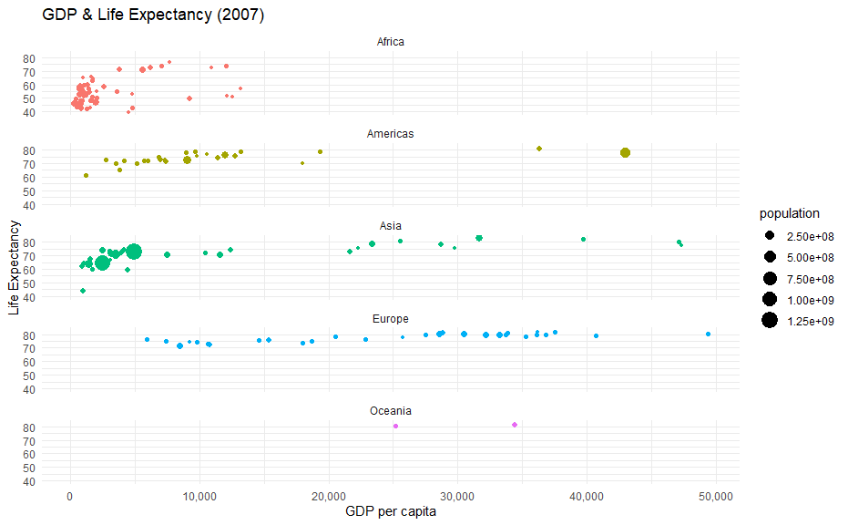

```r
ggplot(gapminder %>% filter(year == 2007),
       aes(x = gdpPercap,
           y = lifeExp,
           color = continent,
           size = pop)) +
  geom_point() +
  facet_wrap(~continent, ncol = 1) +
  theme_minimal() +
  labs(title = "GDP & Life Expectancy (2007)",
       x     = "GDP per capita",
       y     = "Life Expectancy") +
  guides(color = FALSE) +
  scale_size(name = "population",
             labels = function(x) format(x, scientific = TRUE)) +
  scale_x_continuous(labels = comma)
```

## Question 4.4

Select one African country and one Asian country (of your choice). Create a line graph showing the gdpPercap over a 20 year time period. Display the results using one chart (and use a log scale where necessary). Explain the results.

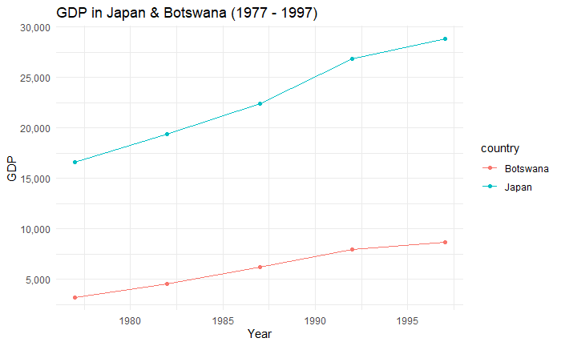

```r
ggplot(
  data = gapminder %>% filter(country %in% c("Japan", "Botswana"),
                     between(year, 1977, 1997)),
  aes(x = year,
      y = gdpPercap,
      group = country,
      color = country)) +
  geom_line() + geom_point() +
  theme_minimal() +
  labs(title = "GDP in Japan & Botswana (1977 - 1997)",
       x     = "Year",
       y     = "GDP") +
  scale_y_continuous(labels = comma,
                     breaks = seq(0, 30000, by = 5000))
```

The results show a steady increase of GDP for both countries during the period of 1977 to 1997, with a slightly steeper increas in Japan. Unsurprisingly, the GDP for a nation as developed as Japan far exceeds that of Botswana.